# Exercise 4. Risk classification

Report

Author

Published

October 9, 2024

## Data visualisation and initial comparison of predictors

Which of the two predictors do you think is the better indicator to classify cancers into malignant or benign?

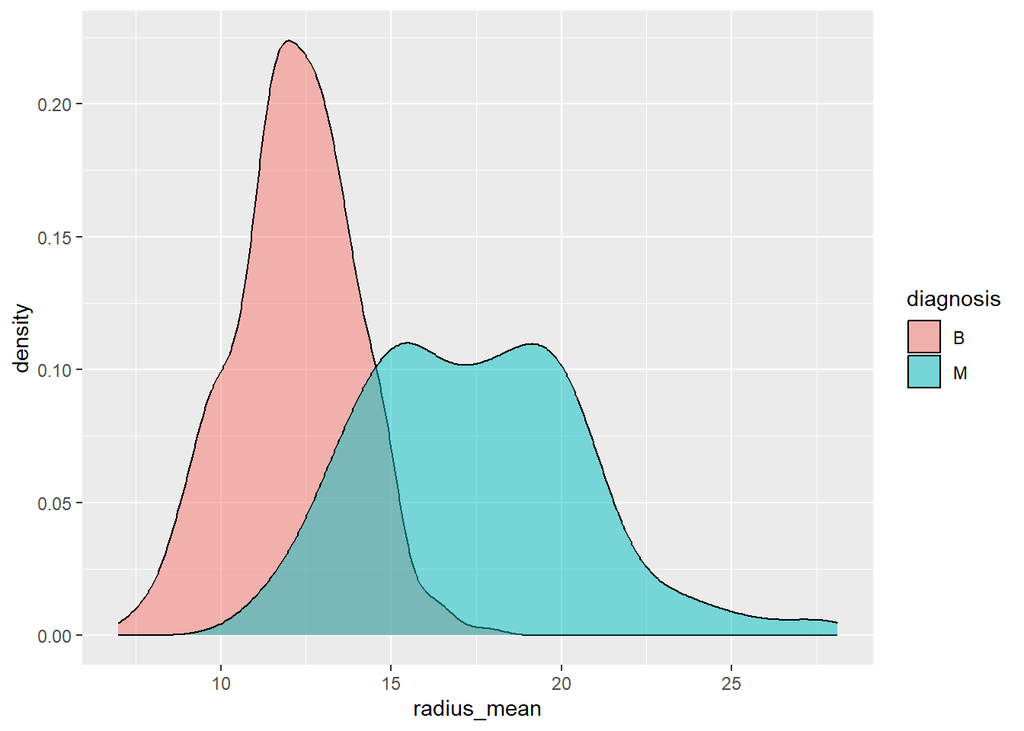

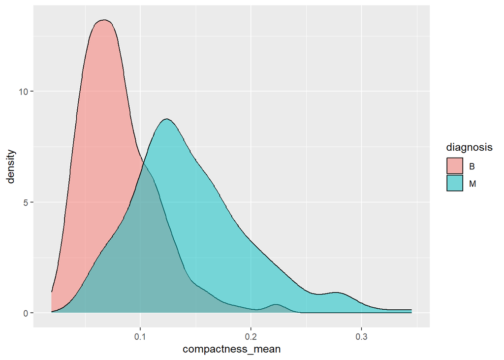

## Frequency of errors for the binary classification model with mean radius as predictor and cutoff 15

For the binary classification model using mean radius as predictor:

Frequency of False positives (FP) is

```
[1] 12
```

Frequency of False negatives (FN) is

```
[1] 51
```

Which of these two errors do you think is worse? Motivate your answer.

## Sensitivity and specificity for the binary classification model with mean radius as predictor and cutoff 15

For the binary classification model using mean radius as predictor:

Frequency of True Positives (TP) is

```
[1] 161
```

Frequency of True Negatives (TN) is

```
[1] 345
```

Sensitivity, i.e. $\frac{TP}{TP + FN}$ is

```
[1] 0.759434
```

Specificity $\frac{TN}{FP + TN}$ is

```
[1] 0.9663866
```

## Model comparison using the ROC curve methodology

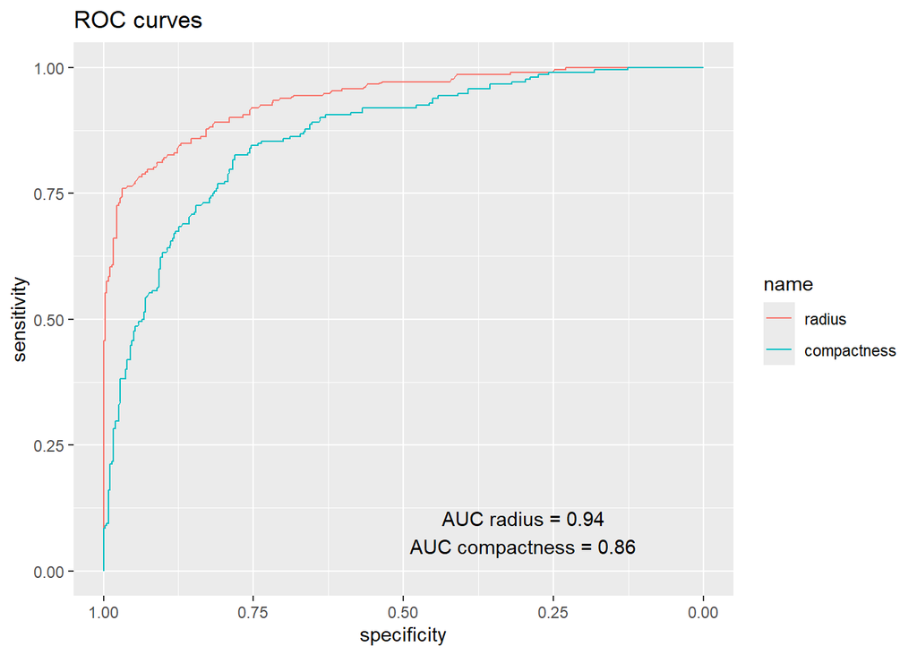

Which of the two binary classification models have the best performance according to the AUC measure?

Suggest three things that could be done to build a better classification model?